# Homework 7

Author: Matthew J. Cossley

Last update: 20 February, 2022

**1.** Considering the following data and using a two-way ANOVA, test the hypothesis that there is a main effect of treatment, a main effect of dose, or an interaction between treatment and dose. Please populate the following variables.

```
##             y treatment dose
##  1: 16.314771         A    1
##  2:  8.368833         A    1
##  3: 16.648996         A    1
##  4: 16.362147         A    1
##  5: 32.073207         A    2
##  6: 22.300250         A    2
##  7: 25.357165         A    2
##  8: 28.526398         A    2
##  9: 39.971164         B    1
## 10: 52.023267         B    1
## 11: 43.817967         B    1
## 12: 36.004954         B    1
## 13: 14.261715         B    2
## 14: 18.552692         B    2
## 15: 18.503924         B    2
## 16: 17.942446         B    2
## 17: 41.261117         C    1
## 18: 35.540394         C    1
## 19: 42.178416         C    1
## 20: 33.812308         C    1
## 21: 18.878661         C    2
## 22: 21.886978         C    2
## 23: 20.666682         C    2
## 24: 24.020948         C    2
##             y treatment dose
```

```r
# Please compute the following by hand as demonstrated in the lecture notes

# Values corresponding to the main effect of treatment
prob_1_theta_hat_obs_treatment <- theta_hat_obs_treatment # observed value of test statistic
prob_1_pval_treatment <- p_val_treatment # p-value of observed test statistic
prob_1_theta_hat_crit_treatment <- theta_hat_crit_treatment # critical value of test statistic

# Values corresponding to the main effect of dose
prob_1_theta_hat_obs_dose <- theta_hat_obs_dose
prob_1_pval_dose <- p_val_dose
prob_1_theta_hat_crit_dose <- theta_hat_crit_dose

# Values corresponding to the interaction of treatment and dose
prob_1_theta_hat_obs_interaction <- theta_hat_obs_interaction
prob_1_pval_interaction <- p_val_interaction
prob_1_theta_hat_crit_interaction <- theta_hat_crit_interaction

# the result of ezANOVA() containing information about both
# main effects and their interaction.
prob_1_r_result <- r_result
```

**2.** Consider the following results

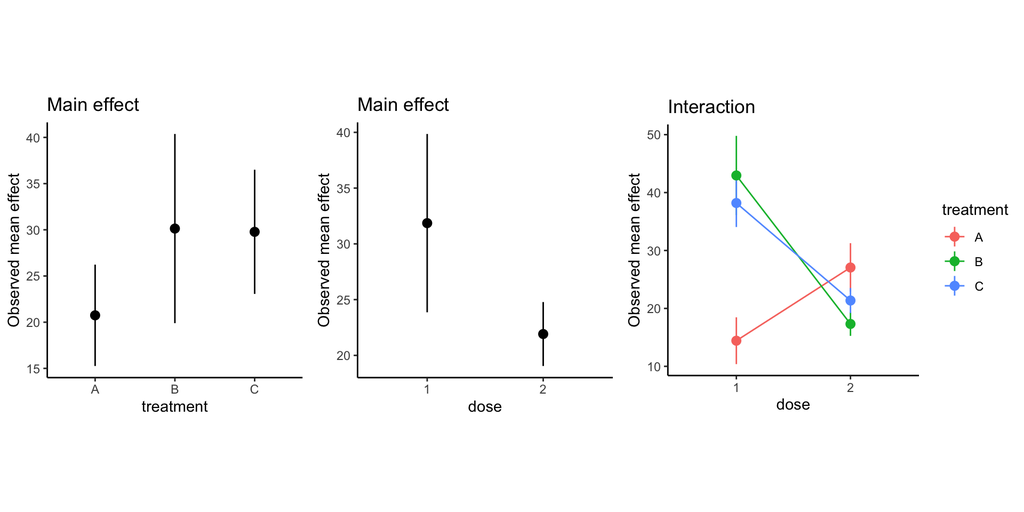

- What effects do you expect to be significant, or close to significant?
  - `ans_2a <- "Dose, treatment, and interaction"`
  - `ans_2a <- "Dose and interaction"`
  - `ans_2a <- "Treatment and interaction"`
  - `ans_2a <- "Dose only"`
  - `ans_2a <- "Treatment only"`
  - `ans_2a <- "Interaction only"`

**3.** Consider the data located here:

https://crossley.github.io/cogs2020/data/maze_2/maze_2.csv

This data contains the results of an experiment in which researchers examined the effect of maze odour and maze material on maze run time in a large sample of rats.

- Every row corresponds to a different rat.
- `y` contains the amount of time in seconds taken to complete the maze.
- `maze_odour` indicates the odour of the maze.
- `maze_material` indicates the material of maze.

Using two-way ANOVA, assess any significant differences between levels of `maze_odour`, `maze_material`, or their interactions?

```r
# You do not have to perform the two-way ANOVA steps
# manually. Please use ezANOVA() and store the result of
# this function to a variable named `ans_3`
ans_3 <- ezANOVA(...)
```

**4.** How many t-tests would you have to perform in order to test all the hypotheses tested in problem 3?

```r
# Your response to this question should be an integer
ans_4 <- 'put_your_integer_answer_here'
```